# UtahLake_TributaryData

#### Provo River

There are two site codes in Provo River (one DWQ and one WFWQC), but these are in the same location. Will compare loads to determine if the estimates can be combined.

Flow

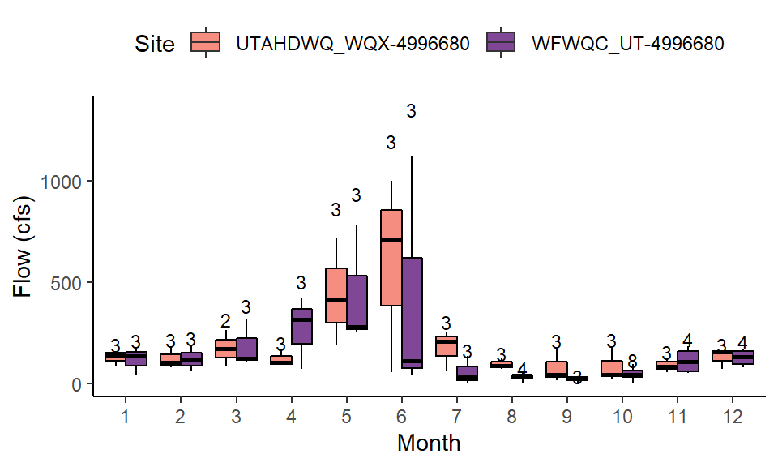

Nutrient loading

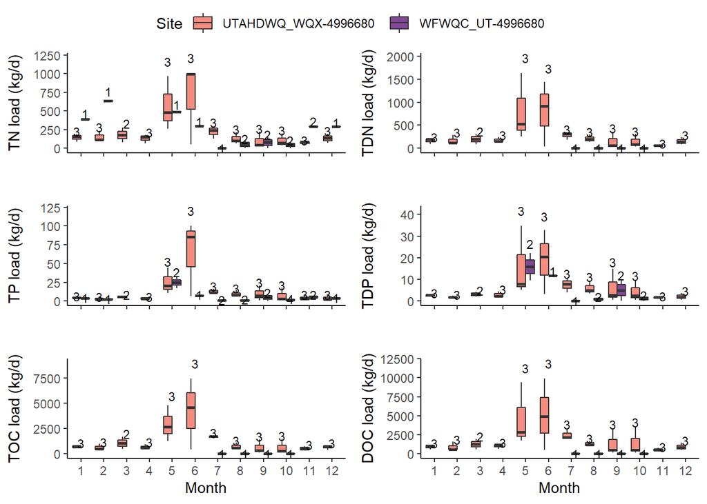

Calculate mean monthly loading

#### Mill Race

Flow

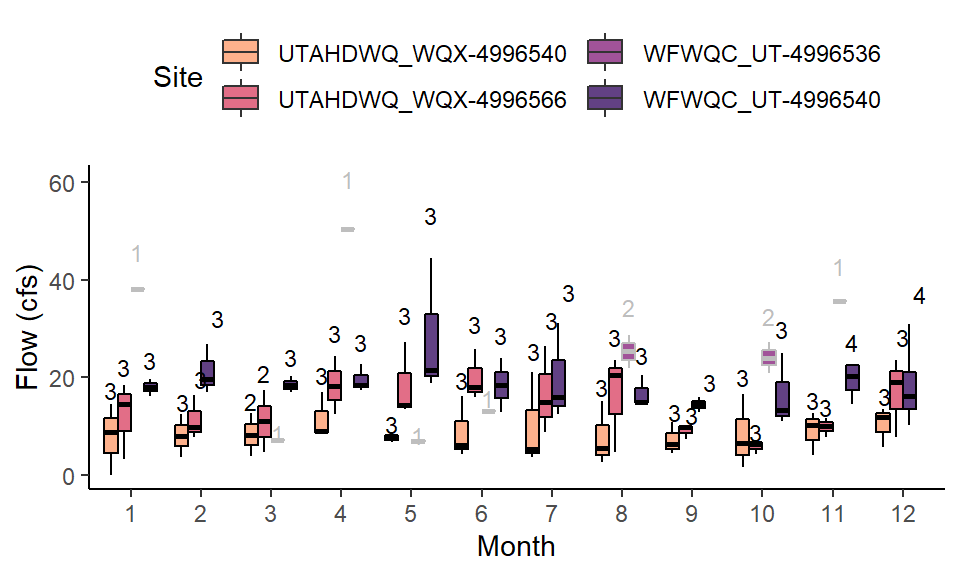

Nutrient loading

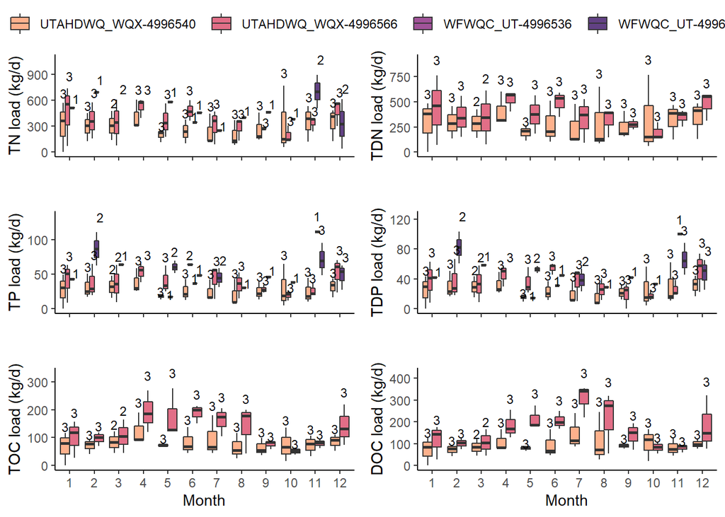

Calculate mean monthly loads

#### Hobble Creek

Flow

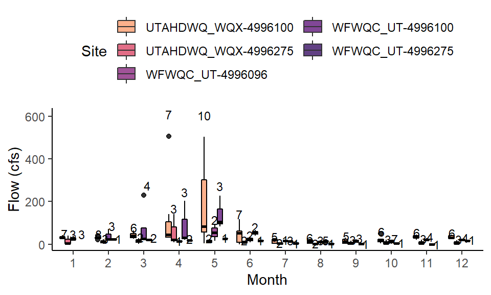

Nutrient loading

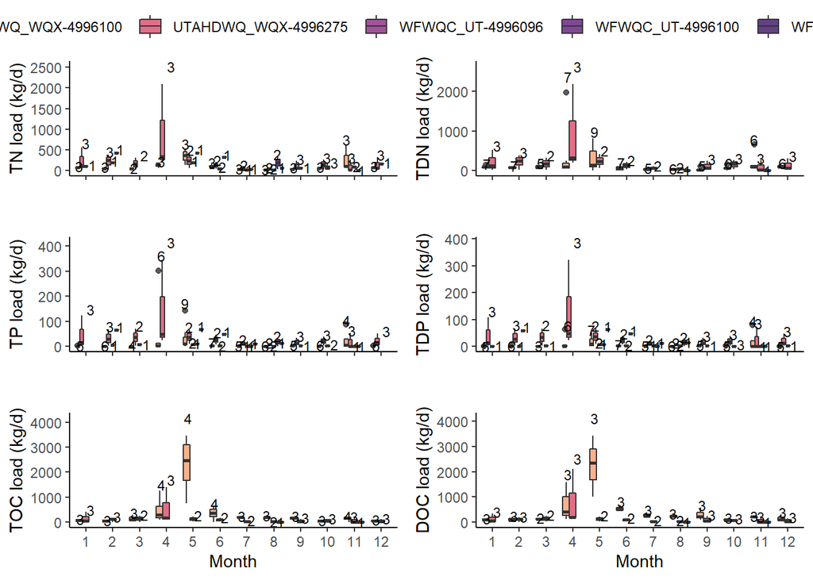

Calculate mean monthly loads

4996096 and 4996100 are equivalent sites. 4996275 is a separate flow representing Springville and represents its own load.

#### Dry Creek - Spanish Fork

Flow

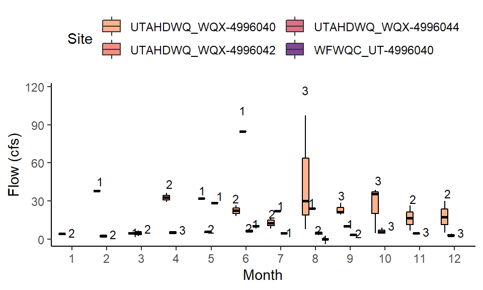

Nutrient loading

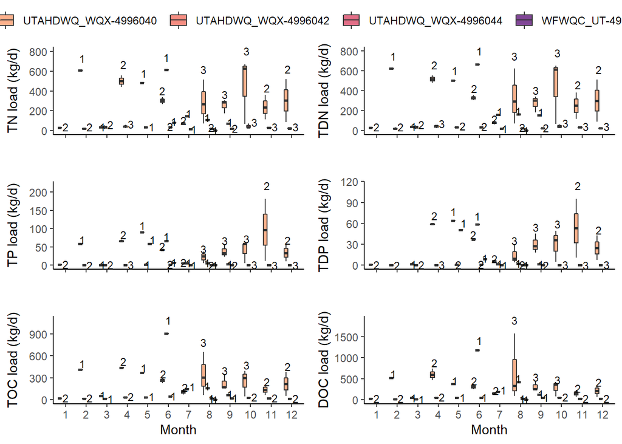

Calculate mean monthly loads

4996040 is the primary site in this watershed and represents the sum total of loads. 4996042 and 4996044 represent equivalent sites for the East tributary but do not include the south fork. East tributary sites will be removed and the primary site used for loads.

#### Spanish Fork River

There are two sites in Spanish Fork River. DWQ site is upstream of WFWQC site. Will compare loads to determine if the estimates can be combined.

Flow

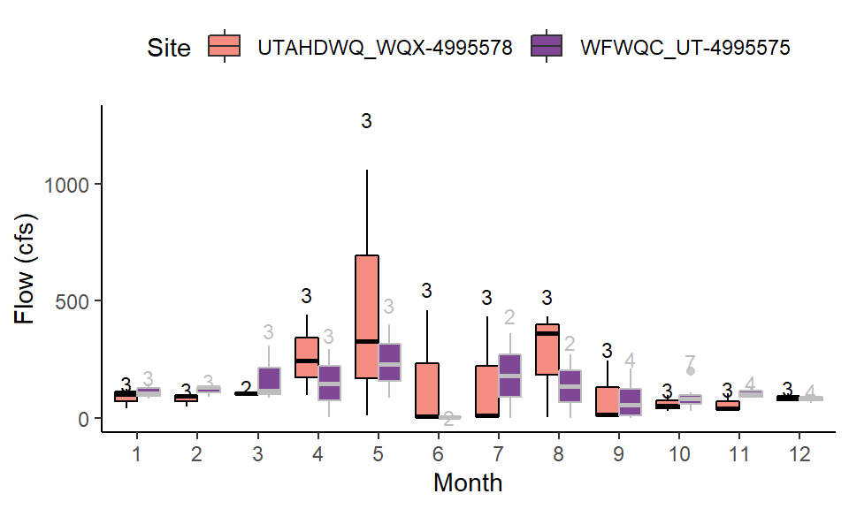

Nutrient loading

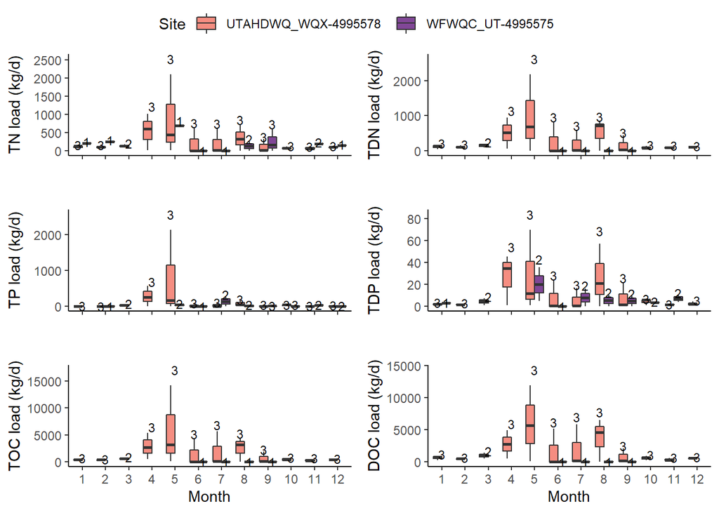

Calculate mean monthly loading

#### 4000 South Drain Spanish Fork

There are two sites in 4000 South Drain Spanish Fork. DWQ site is upstream of WFWQC site. Will compare loads to determine if the estimates can be combined.

Flow

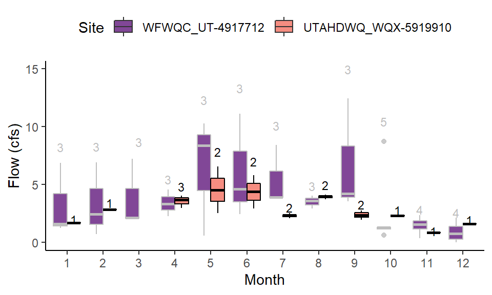

Nutrient loading

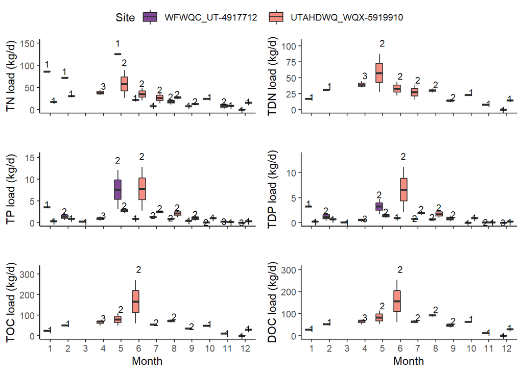

Calculate mean monthly loading

#### Benjamin Slough

There are two sites in Benjamin Slough. DWQ site is upstream of WFWQC site. Will compare loads to determine if the estimates can be combined.

Flow

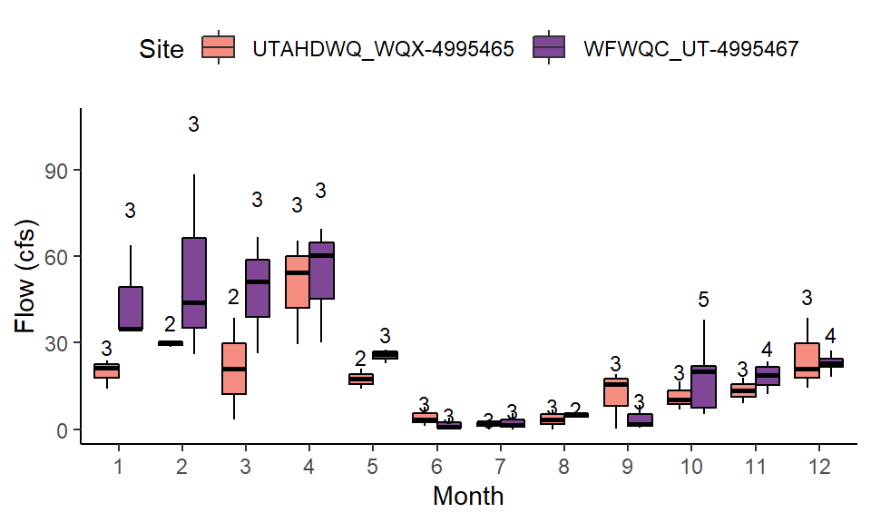

Nutrient loading

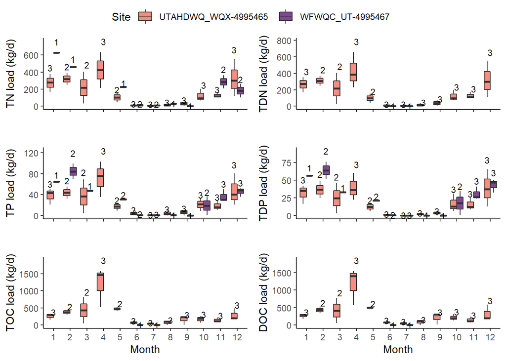

Calculate mean monthly loading

#### Currant Creek

Two sites, UTAHDWQ_WQX-4995310 and UTAHDWQ_WQX-4995312, are located at the same coordinates. These sites are pooled in load calculations, as they represent the same location.

Flow

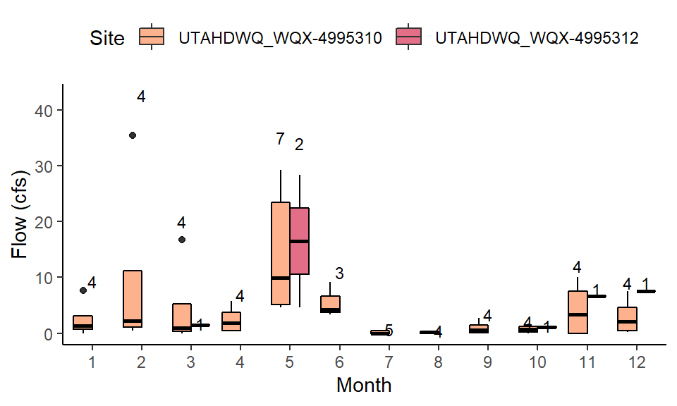

Nutrient loads

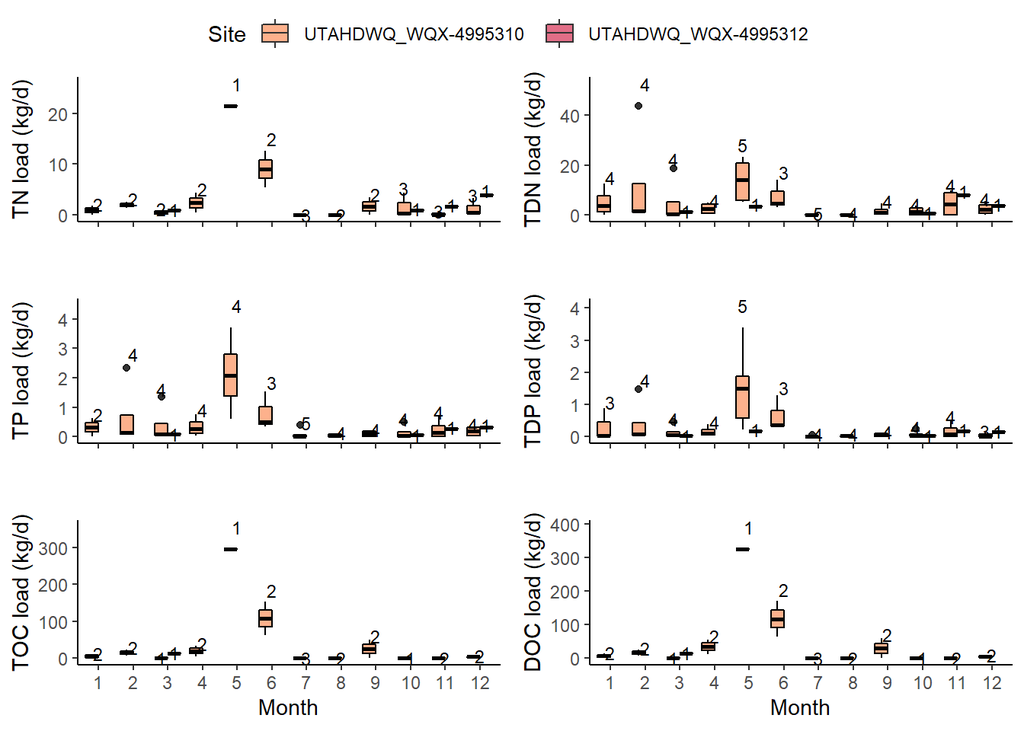

Calculate mean monthly loading

### Monthly load across watersheds

```r
loading_AllWatersheds <- rbind(
  loading_LakeMountainIsraelCanyon, loading_DryCreekSaratoga,
  loading_LehiSpringCreek, loading_AmericanForkRiver, loading_TimpSSD,
  loading_LindonDrain, loading_PowellSloughMajor, loading_ProvoRiver,
  loading_MillRace, loading_HobbleCreek, loading_DryCreekSpanishFork,
  loading_SpanishFork, loading_4000SouthDrain, loading_BenjaminSlough,
  loading_CurrantCreek)
```

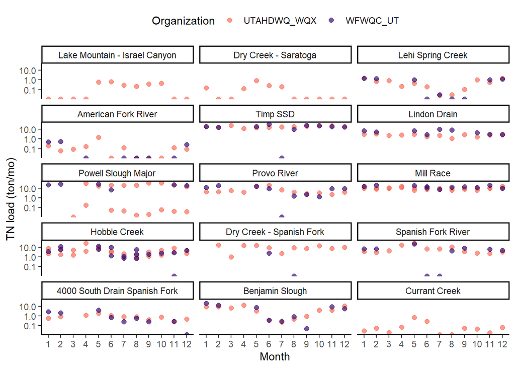

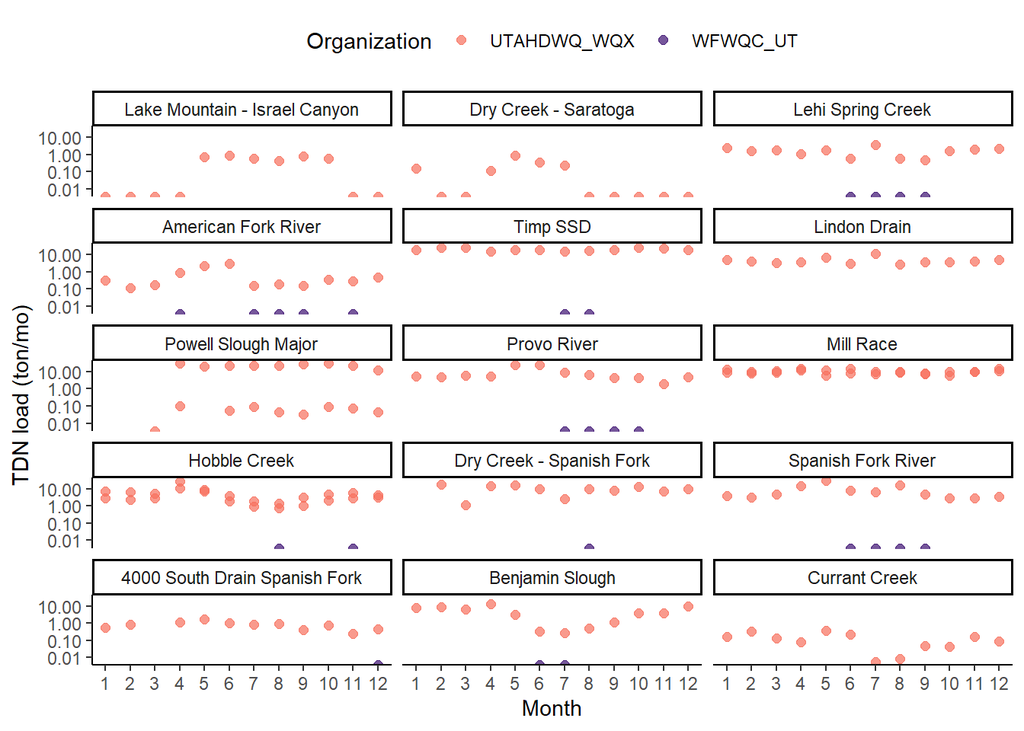

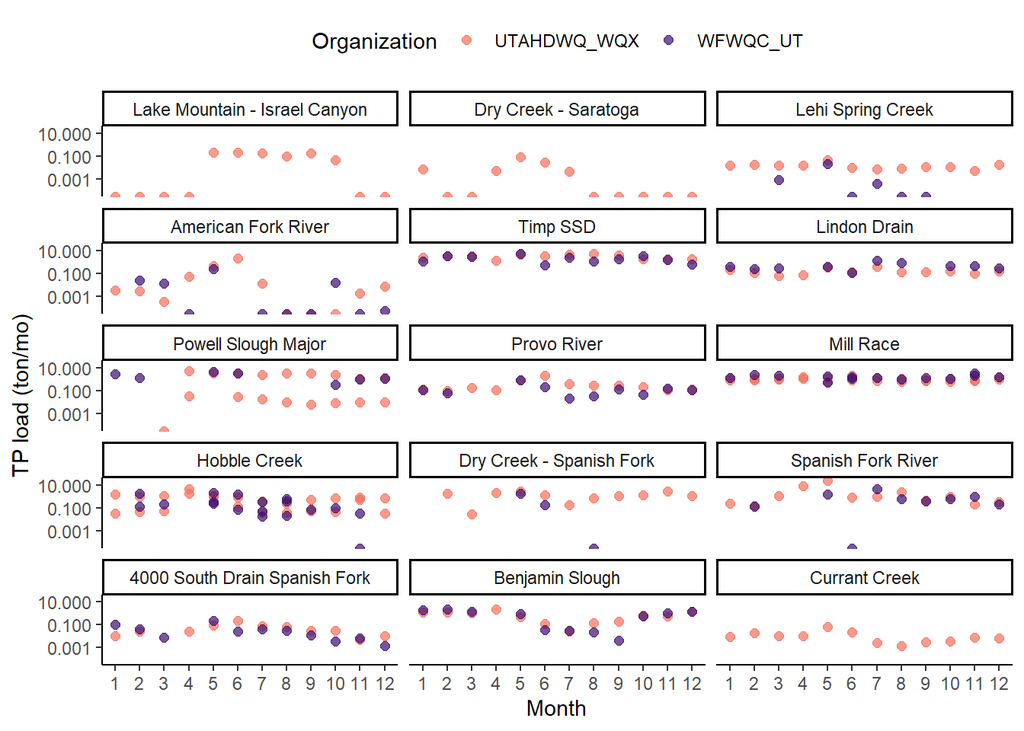

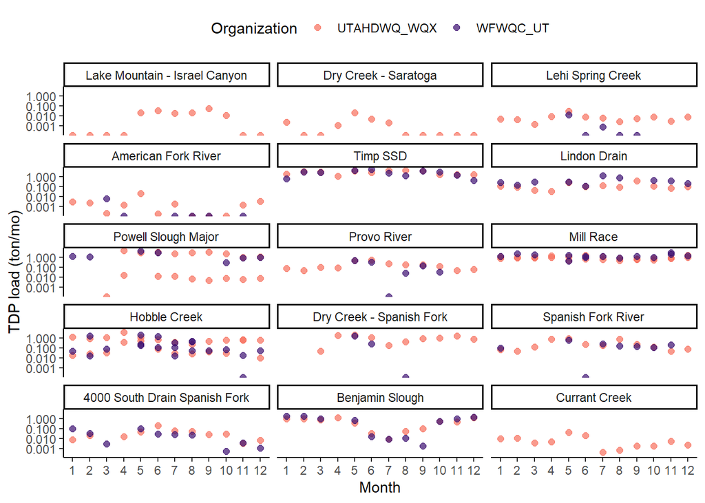

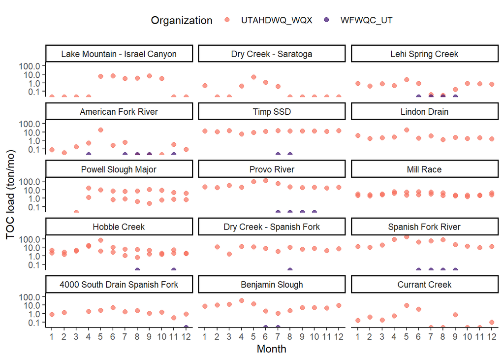

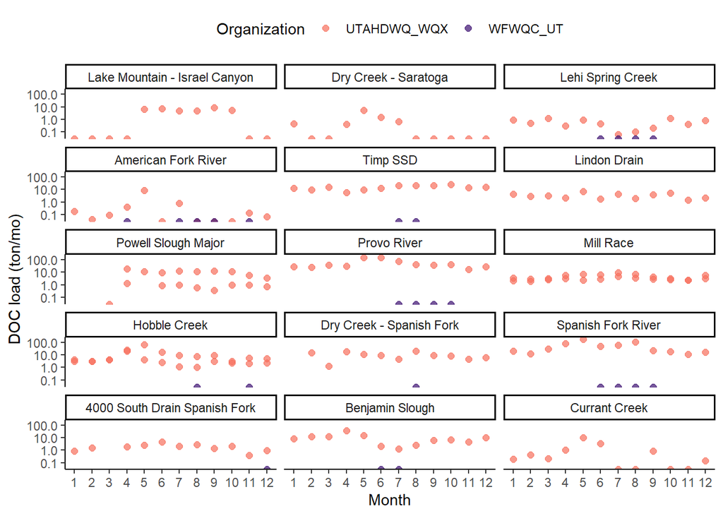

### C-Q

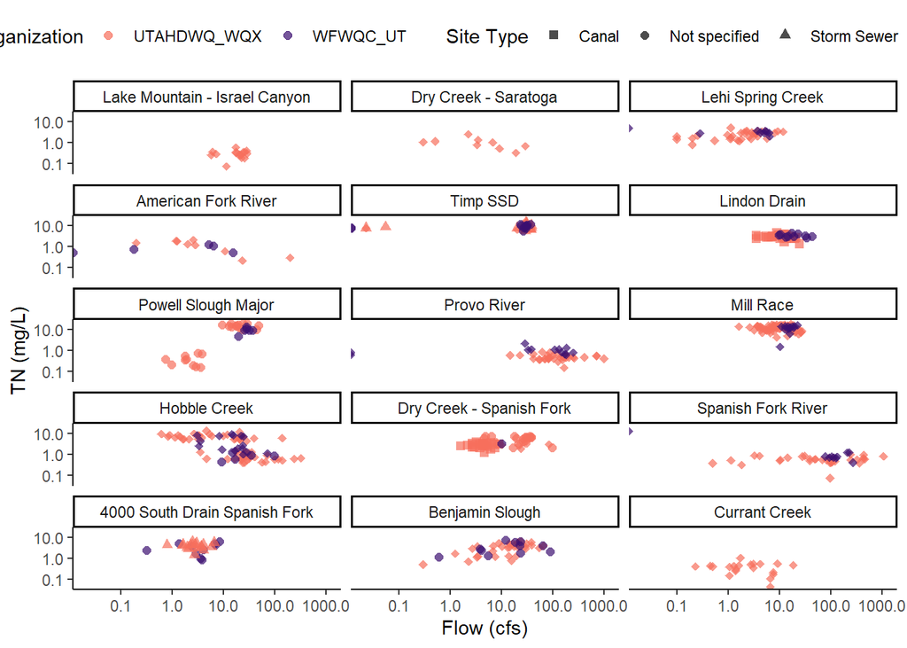

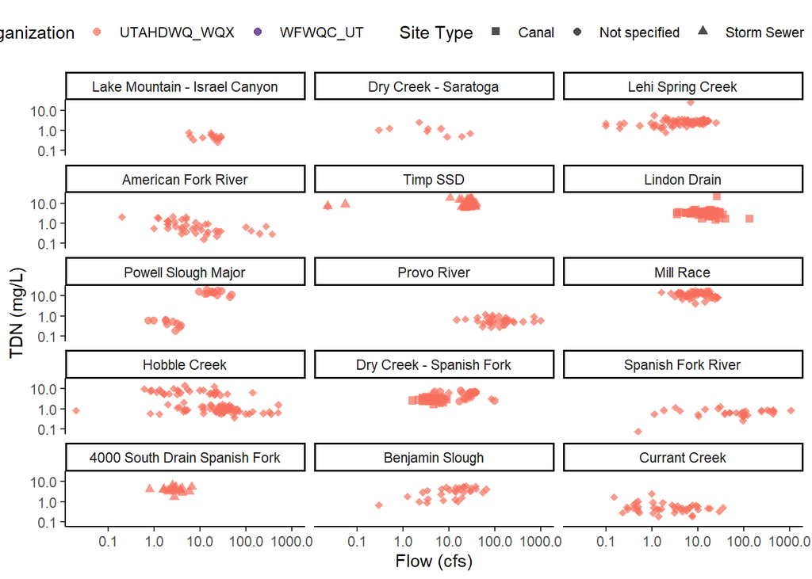

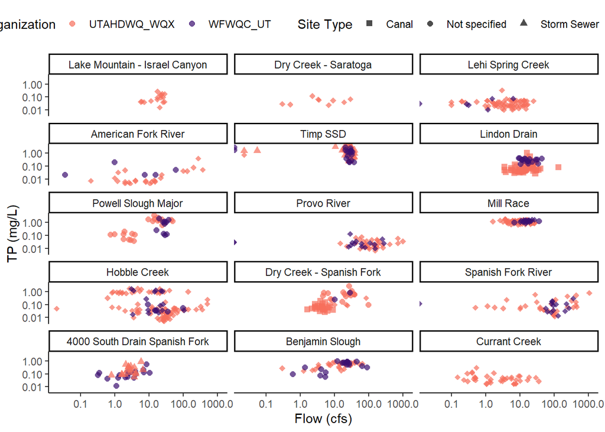

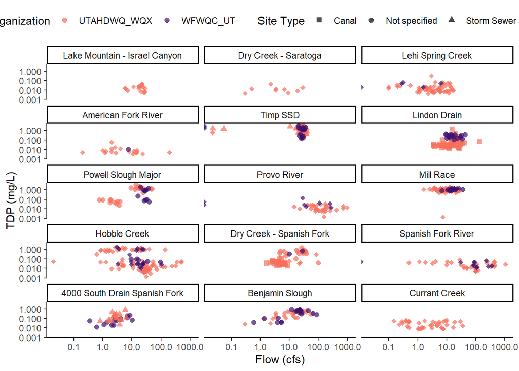

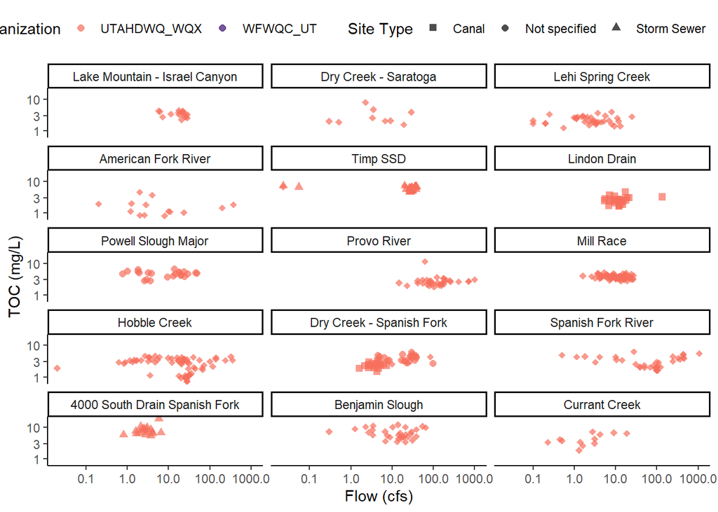

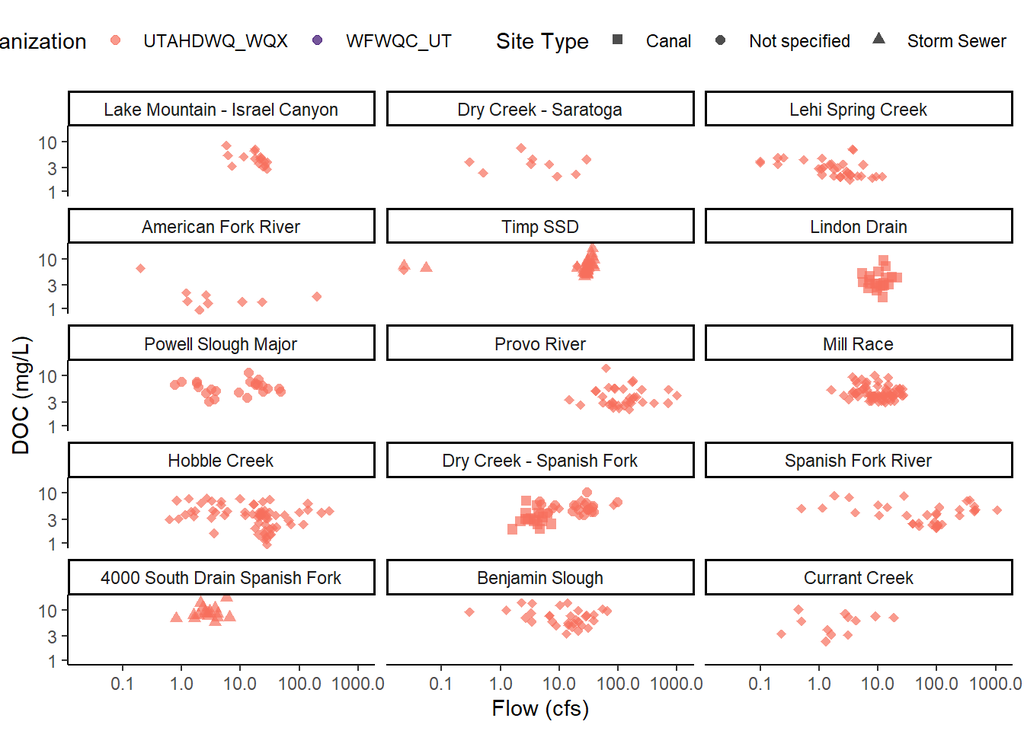

### Precipitation and evaporation

TO DO: Change y axis to volumes after determining monthly lake area

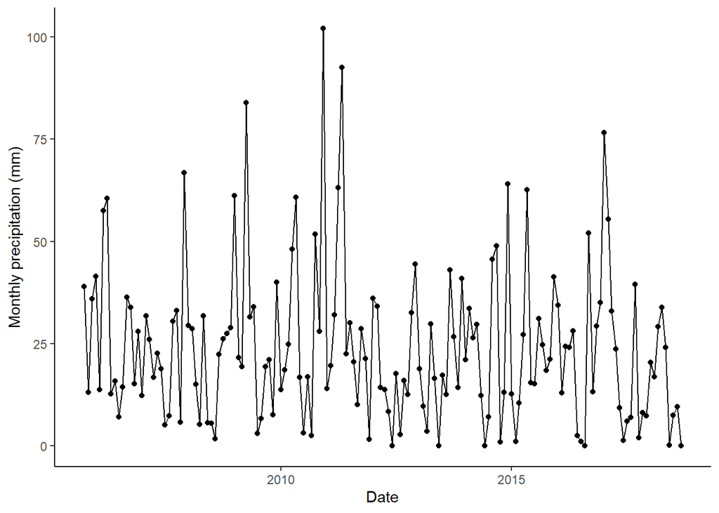

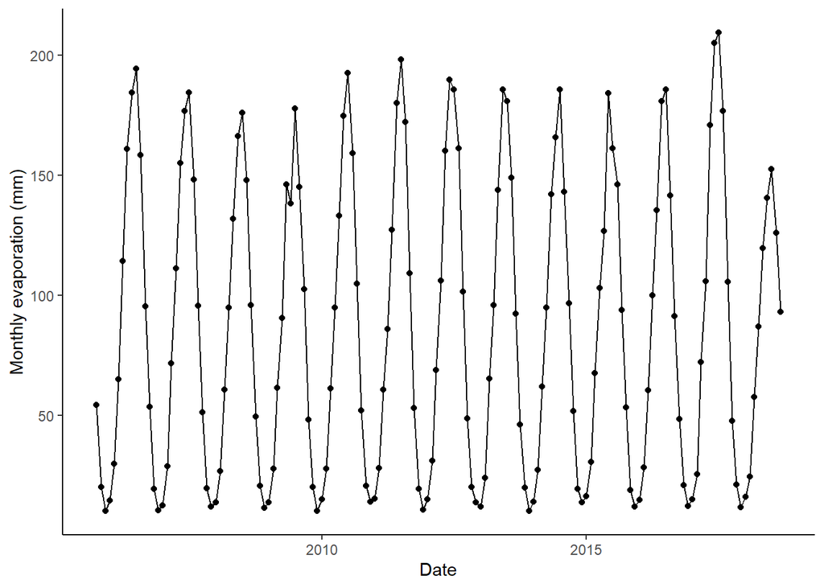

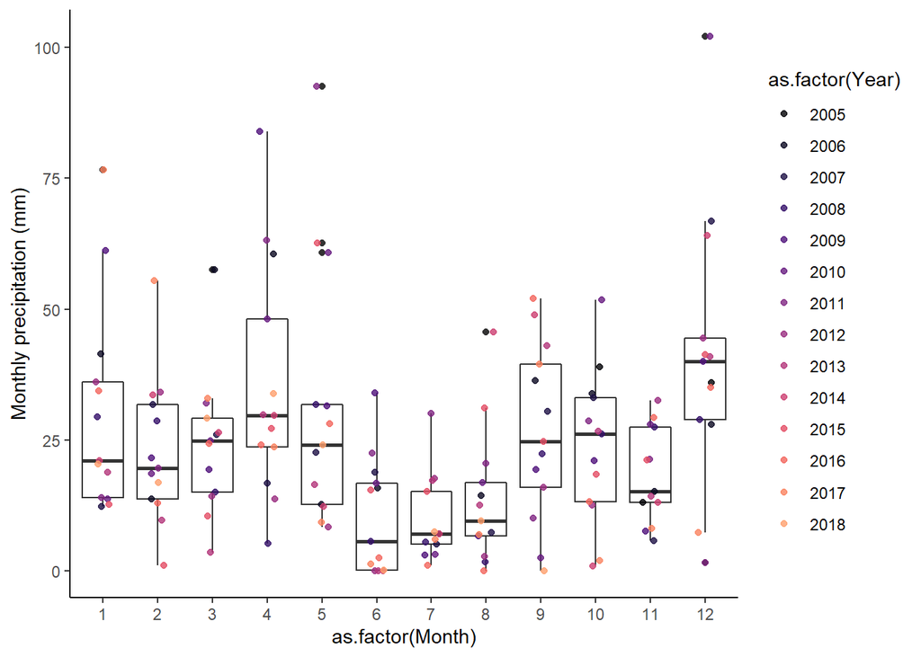

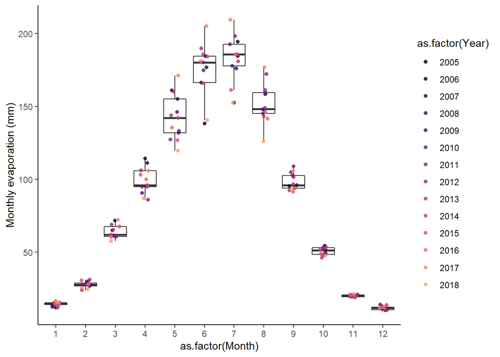

## Appendix

### Nutrient concentrations across watersheds

#### Lake Mountain - Israel Canyon

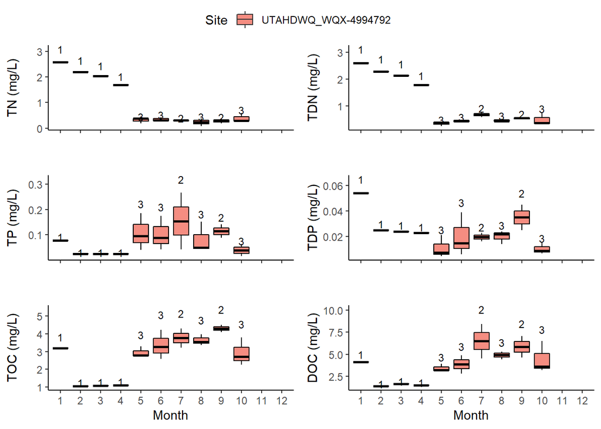

#### Dry Creek - Saratoga

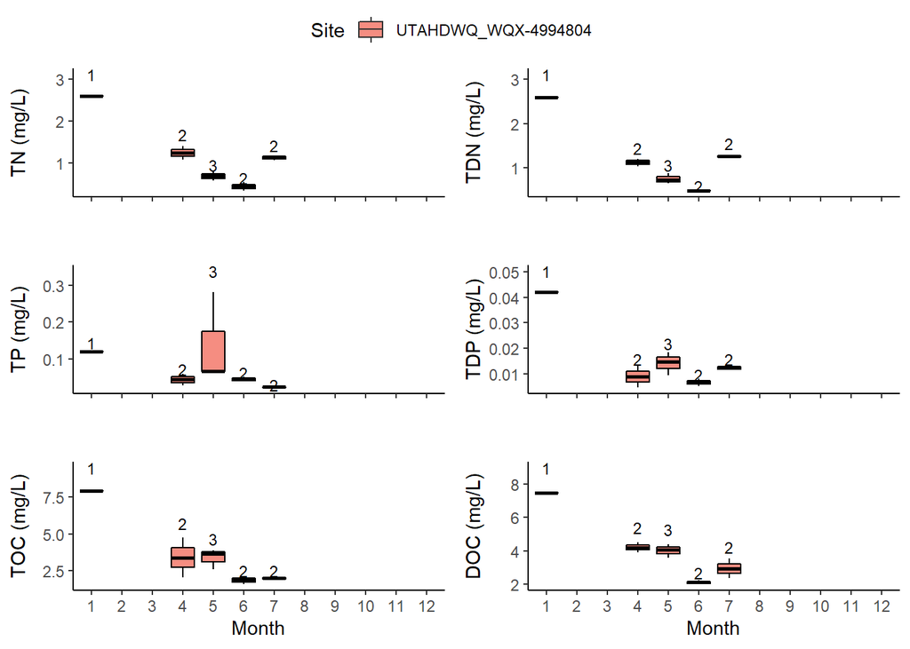

#### Lehi Spring Creek

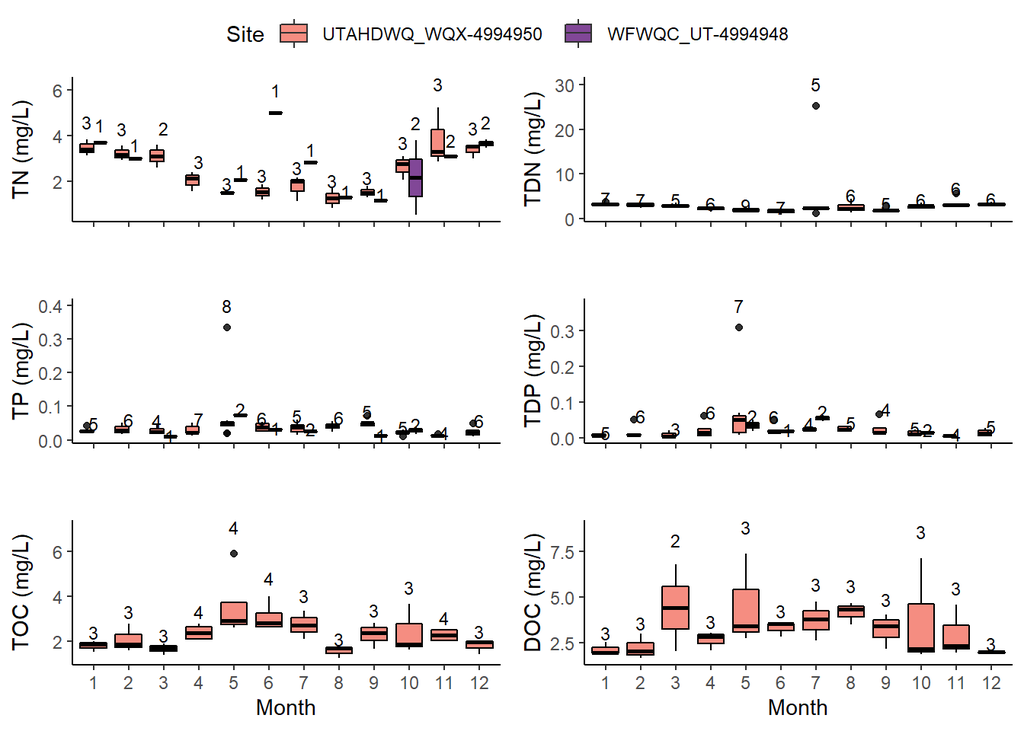

#### American Fork River

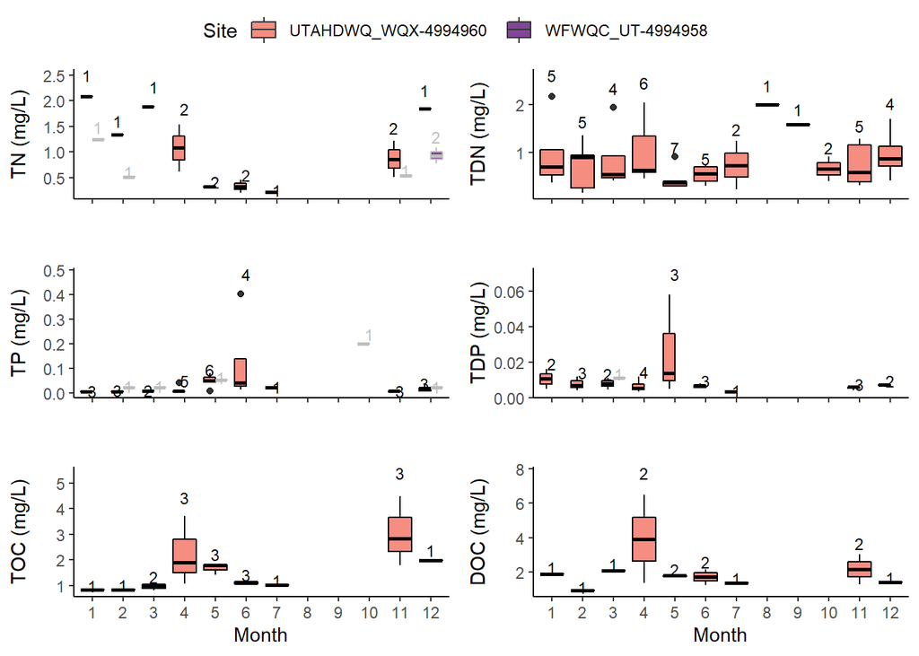

#### Timp SSD

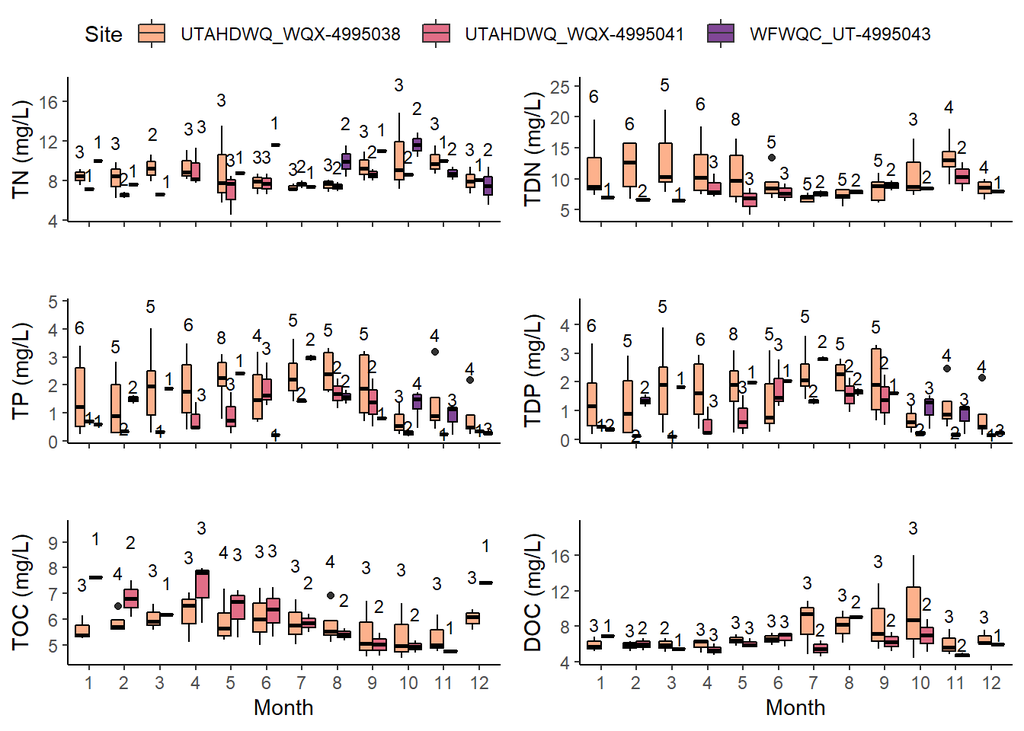

#### Lindon Drain

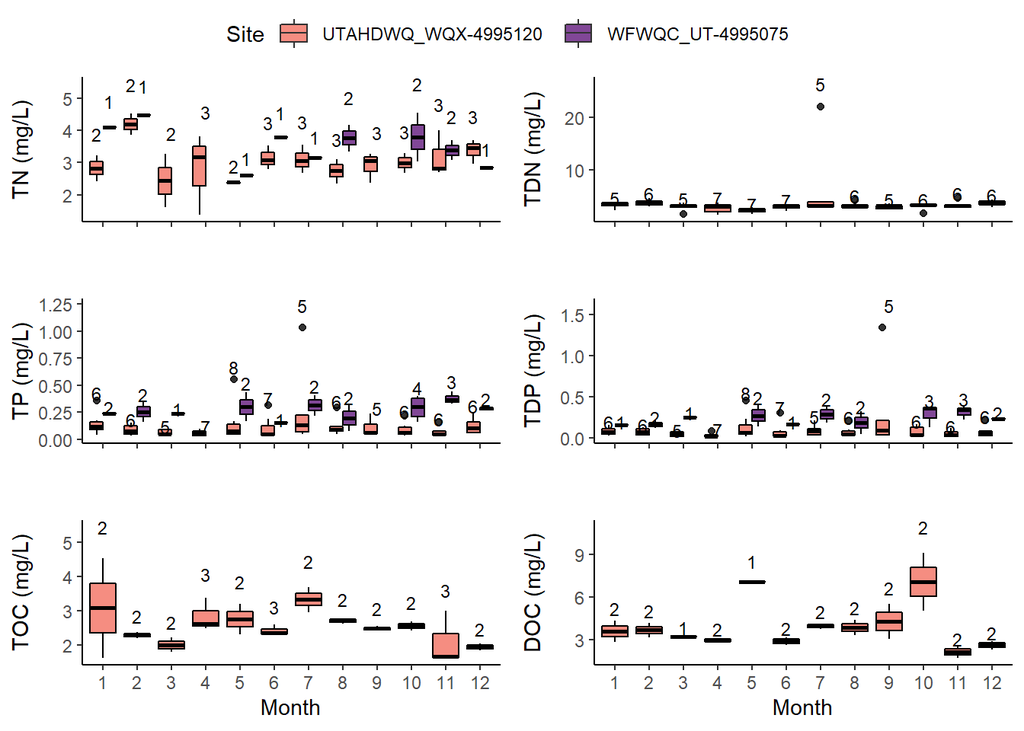

#### Powell Slough Major

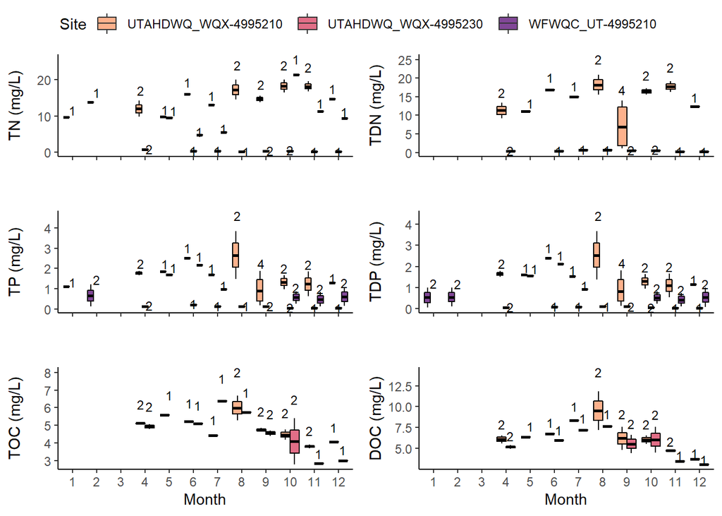

#### Provo River

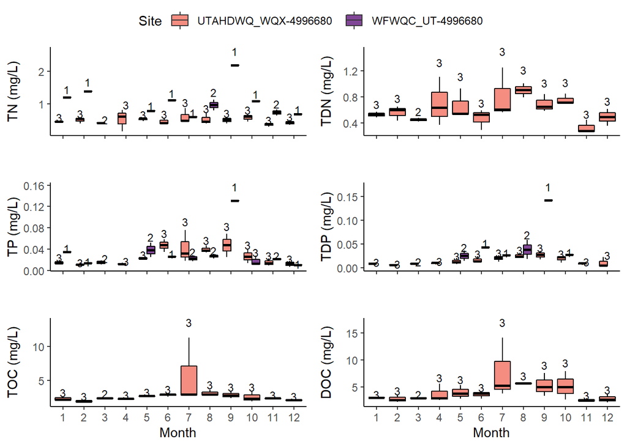

#### Mill Race

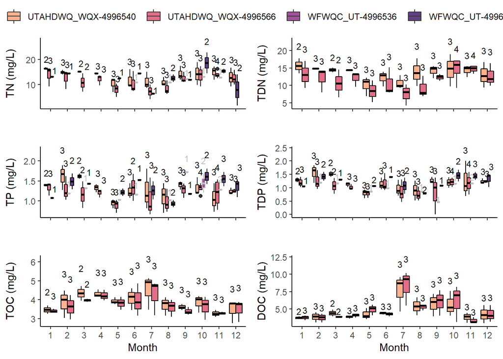

#### Hobble Creek

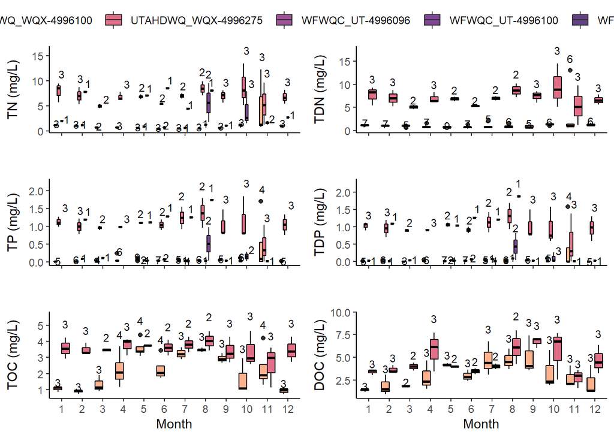

#### Dry Creek - Spanish Fork

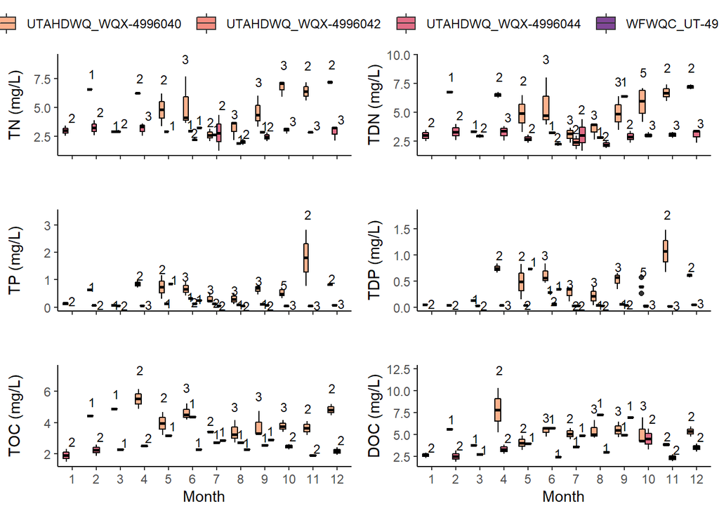

#### Spanish Fork River

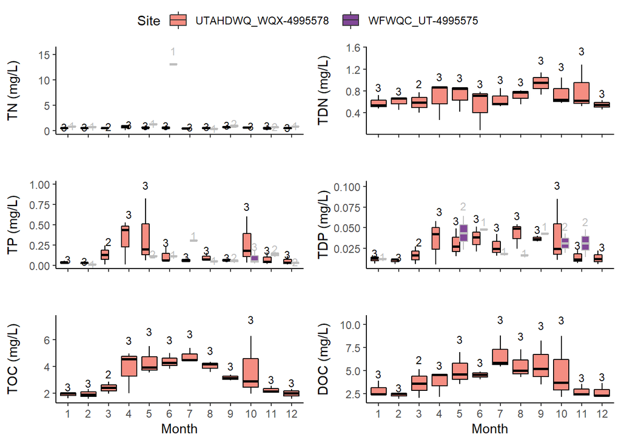

#### 4000 South Drain Spanish Fork

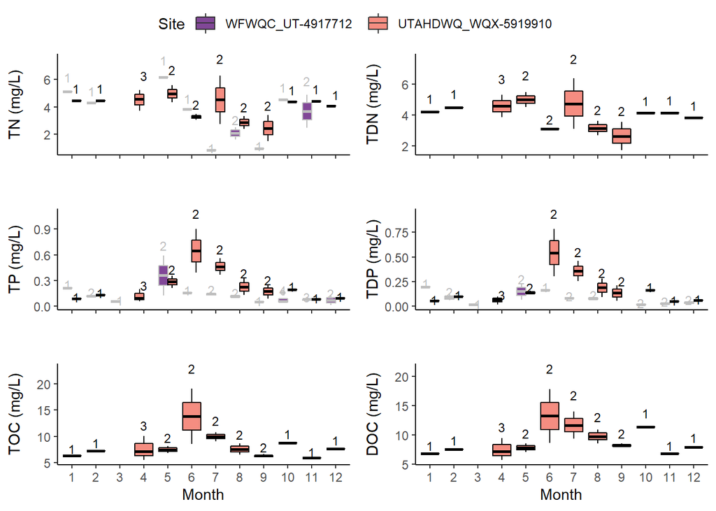

#### Benjamin Slough

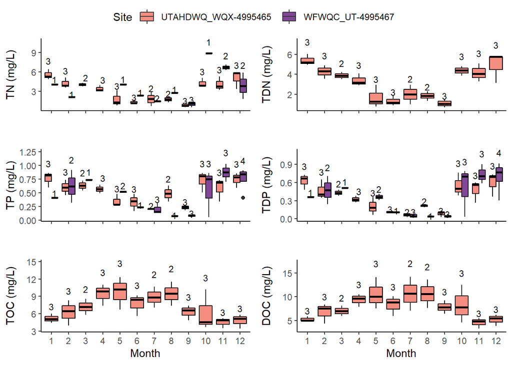

#### Currant Creek

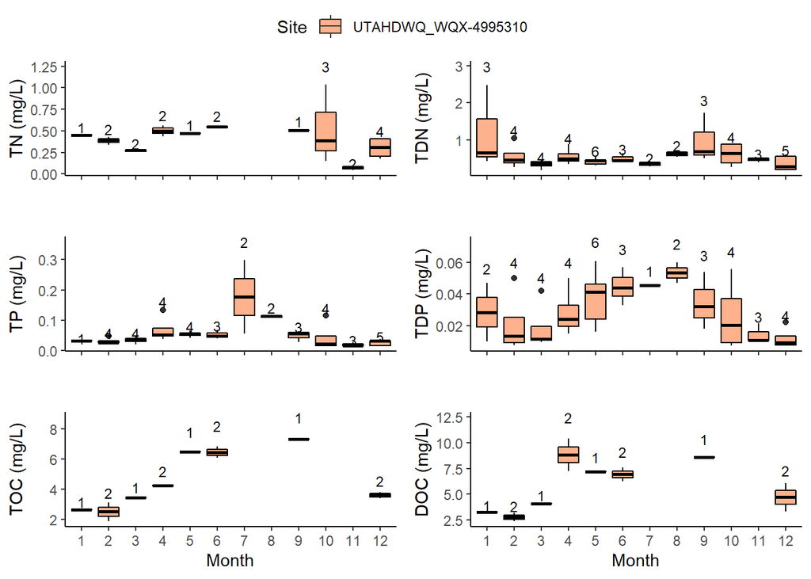